# HW3 - Text Mining

Tao Huang

October 14, 2020

##APIs Using the NCBI API, look for papers that show up under the term “sars-cov-2 trial vaccine.” Look for the data in the pubmed database, and then retrieve the details of the paper as shown in lab 7. How many papers were you able to find?

Using the list of pubmed ids you retrieved, download each papers’ details using the query parameter rettype = abstract. If you get more than 250 ids, just keep the first 250.

As we did in lab 7. Create a dataset containing the following:

Pubmed ID number, Title of the paper, Name of the journal where it was published, Publication date, and Abstract of the paper (if any).

```r
knitr::opts_chunk$set(echo = TRUE)
```

```r
library(tidyverse)
library(data.table)
library(dplyr)
library(httr)
library(xml2)
library(stringr)     # extract the text....

web <- xml2::read_html("https://pubmed.ncbi.nlm.nih.gov/?term=sars-cov-2+trial+vaccine")

#counts the results
count <- xml2::xml_find_first(web,
                 "/html/body/main/div[9]/div[2]/div[2]/div[1]/span")  # full_xpath
count <- as.character(count)
str_extract(count, "[0-9,]+")
```

```
## [1] "564"
```

*There are 564 results/papers related to term of “sars-cov-2 trial vaccine” in the PubMed database* Pubmed ID number, Title of the paper, Name of the journal where it was published, Publication date, and Abstract of the paper (if any).

```r
#extract Pubmed ID number of containing key term"sars-cov-2 trial vaccine"
query_id <- GET(
  url   = "https://eutils.ncbi.nlm.nih.gov/entrez/eutils/esearch.fcgi",  #ESearch (text searches)
  query = list(
               db="pubmed",
               term="sars-cov-2 trial vaccine",
               retmax=250
               )
)


id<-content(query_id)


#extract "<Id>[0-9]+</Id>"
id <- str_extract_all(id, "<Id>[0-9]+</Id>")[[1]]  #attention!
##remove <Id> </Id>

id<-str_remove_all(id, "<Id>|</Id>")

typeof(id)
```

```
## [1] "character"
```

```r
publica <- GET(
  url = "https://eutils.ncbi.nlm.nih.gov/entrez/eutils/efetch.fcgi",
  query = list(
    db = "pubmed",
    id = paste(id, collapse=","),
      retmax = 250,
    rettype = "abstract"
    )
)


publica <- content(publica)
publica_txt <- as.character(publica)
```

```r
###Form a database
pub_char <- xml_children(publica)
#Splits
pub_char <- sapply(pub_char, as.character)


##extract the content
#Abstract of the paper (if any)
abstract <- str_extract(pub_char, "<Abstract>(\\n|.)+</Abstract>")
abstract <- str_remove_all(abstract, "</?[[:alnum:]]+>")
abstract <- str_replace_all(abstract, "\\s+", " ")
table(is.na(abstract))
```

```
##
## FALSE  TRUE
##   167    62
```

```r
#Title of the paper
title <- str_extract(pub_char, "<ArticleTitle>(\\n|.)+</ArticleTitle>")
title <- str_remove_all(title, "</?[[:alnum:]]+>")
title <- str_replace_all(title, "\\s+", " ")
table(is.na(title))
```

```
##
## FALSE
##   229
```

```r
#Publication date
date <- str_extract(pub_char, "<PubDate>(\\n|.)+</PubDate>")
date <- str_remove_all(date, "</?[[:alpha:]]+>")
date <- str_remove_all(date, "\n")
date <- str_remove_all(date, "</?[[:punct:]]+>")


#Name of the journal where it was published,
journal <- str_extract(pub_char, "<MedlineTA>(\\n|.)+</MedlineTA>")
```

```r
DataBase <- data.frame(
  PubMedID = id,
  Title = title,
  Abstract = abstract,
  PublicationDate=date,
  JournalAbbrevation=journal
)


##knitr---like print format
knitr::kable(DataBase)
```

| PubMedID | Title | Abstract | PublicationDate | JournalAbbrevation |
| --- | --- | --- | --- | --- |
| 33043110 | EXPLORING SURFACE GLYCOPROTEIN TO DESIGN MULTI-EPITOPE VACCINE AGAINST COVID-19. | Stimulation and generation of T and B cell mediated long-term immune response is essential for the curbing of a deadly virus such as SAR-CoV-2. Immunoinformatics approach in vaccine design takes advan… | 2020 Oct 04 | Inform Med Unlocked |
| 33042591 | Impact of COVID-19 on clinical trials and clinical research: A systematic review. | Background: The World Health Organization has reported more than 31,186,000 confirmed cases of coronavirus disease-19 (COVID-19), including 962,343 deaths, worldwide as on September 21, 2020. The curr… | 2020 Sep | Nepal J Epidemiol |
| 33038433 | COVID-19: discovery, diagnostics and drug development. | An epidemic of acute respiratory syndrome (Covid-19) started in humans in Wuhan in 2019, and became a pandemic. Groups from China Identified and sequenced the virus responsible for COVID-19, named SAR… | 2020 Oct 07 | J Hepatol |
| 33022293 | Clinical trial protocols of repurposed prophylaxis for COVID-19: a review. | Efficient therapeutic strategies are needed to counter the COVID-19 pandemic, caused by the SARS-CoV-2 virus. In a context where specific vaccines are not yet available, the containment of the pandemi… | 2020 Oct 03 | Med Mal Infect |
| 33013255 | Screening of FDA Approved Drugs Against SARS-CoV-2 Main Protease: Coronavirus Disease. | At the end of December 2019, a new strain of coronavirus was identified in the Wuhan city of Hubei province in China. Within a shorter period of time, an unprecedented outbreak of this strain was witn… | 2020 Sep 28 | Int J Pept Res Ther |
| 33012348 | SARS-CoV-2 Vaccine Development: Current Status. | In the midst of the severe acute respiratory syndrome coronavirus 2 pandemic and its attendant morbidity and mortality, safe and efficacious vaccines are needed that induce protective and long-lived i… | 2020 10 | Mayo Clin Proc |
| 32998488 | Status of COVID-19 vaccine development. | NA | 2020 09 29 | Tidsskr Nor Laegeforen |
| 32998157 | COVID-19 vaccine BNT162b1 elicits human antibody and TH1 T cell responses. | An effective vaccine is needed to halt the spread of the severe acute respiratory syndrome coronavirus-2 (SARS-CoV-2) pandemic. Recently, we reported safety, tolerability and antibody response data fr… | 2020 Sep 30 | Nature |
| 32997699 | Analysis of COVID-19 clinical trials: A data-driven, ontology-based, and natural language processing approach. | With the novel COVID-19 pandemic disrupting and threatening the lives of millions, researchers and clinicians have been recently conducting clinical trials at an unprecedented rate to learn more about… | 2020 | PLoS One |
| 32994572 | COVID vaccine confidence requires radical transparency. | NA | 2020 10 | Nature |
| 32991794 | Safety and Immunogenicity of SARS-CoV-2 mRNA-1273 Vaccine in Older Adults. | Testing of vaccine candidates to prevent infection with severe acute respiratory syndrome coronavirus 2 (SARS-CoV-2) in an older population is important, since increased incidences of illness and deat… | 2020 Sep 29 | N Engl J Med |
| 32988688 | Intention to participate in a COVID-19 vaccine clinical trial and to get vaccinated against COVID-19 in France during the pandemic. | The world is facing the COVID-19 pandemic. The development of a vaccine is challenging. We aimed to determine the proportion of people who intend to get vaccinated against COVID-19 in France or to par… | 2020 10 21 | Vaccine |
| 32985963 | Coronavirus Disease 2019 Vaccine Development: An Overview. | To this day, the coronavirus disease 2019 (COVID-19) pandemic has not shown signs of abating. Moreover, the virus responsible for the pandemic, severe acute respiratory syndrome coronavirus 2, has evo… | 2020 Sep 23 | Viral Immunol |
| 32979327 | The arrival of Sputnik V. | NA | 2020 10 | Lancet Infect Dis |
| 32978611 | COVID-vaccine results are on the way - and scientists’ concerns are growing. | NA | 2020 10 | Nature |
| 32974268 | Overview of the First 6 Months of Clinical Trials for COVID-19 Pharmacotherapy: The Most Studied Drugs. | SARS-CoV-2 rapidly spread from China until it was defined a pandemic by WHO in March 2020. Related scientific papers have rapidly extended information regarding the diagnosis, treatment and epidemiolo… | 2020 | Front Public Health |
| 32973779 | The 2020 Pandemic: Current SARS-CoV-2 Vaccine Development. | Coronaviruses are enveloped viruses with a positive-sense single-stranded RNA genome infecting animals and humans. Coronaviruses have been described more than 70 years ago and contain many species. Se… | 2020 | Front Immunol |
| 32969973 | Coronavirus disease-19 vaccine development utilizing promising technology. | Coronavirus disease-19 (COVID-19) is a highly transmittable and pathogenic pneumonia-causing disease, which is caused by severe acute respiratory syndrome coronavirus-2, resulting in millions of death… | 2020 11 | Curr Opin HIV AIDS |
| 32969369 | Safety and Efficacy of Different Therapeutic Interventions on Prevention and Treatment of COVID-19. | Severe acute respiratory syndrome coronavirus 2 (SARS-CoV-2) is the strain of coronavirus that causes coronavirus disease 2019 (COVID-19), a respiratory illness. COVID-19 has now become a global publi… | 2020 Sep 07 | J Nepal Health Res Counc |
| 32967006 | SARS-CoV-2 vaccines in development. | Severe acute respiratory syndrome coronavirus 2 (SARS-CoV-2) was first reported in late 2019 in China and is the causative agent of the coronavirus disease 2019 (COVID-19) pandemic. To mitigate the ef… | 2020 Sep 23 | Nature |
| 32963672 | Expedited COVID-19 vaccine trials: a rat-race with challenges and ethical issues. | The intense global efforts are directed towards development of vaccines to halt the COVID-19 virus pandemic. There are 160 candidate vaccines under clinical trials across the world using different mol… | 2020 | Pan Afr Med J |
| 32958009 | The use of mesenchymal stromal cells in the treatment of coronavirus disease 2019. | More than seven months into the coronavirus disease -19 (COVID-19) pandemic, infection from the severe acute respiratory syndrome coronavirus-2 (SARS-CoV-2) has led to over 21.2 million cases and resu… | 2020 09 21 | J Transl Med |
| 32943115 | Using BCG vaccine to enhance non-specific protection of health care workers during the COVID-19 pandemic: A structured summary of a study protocol for a randomised controlled trial in Denmark. | The Bacille Calmette-Guérin (BCG) vaccine against tuberculosis is associated with non- specific protective effects against other infections, and significant reductions in all-cause morbidity and morta… | 2020 Sep 17 | Trials |
| 32934758 | Tuberculosis and COVID-19: Lessons from the Past Viral Outbreaks and Possible Future Outcomes. | The threat of contagious infectious diseases is constantly evolving as demographic explosion, travel globalization, and changes in human lifestyle increase the risk of spreading pathogens, leading to … | 2020 | Can Respir J |
| 32934375 | Researchers highlight ‘questionable’ data in Russian coronavirus vaccine trial results. | NA | 2020 09 | Nature |
| 32933536 | Pathophysiology and treatment strategies for COVID-19. | The outbreak of Coronavirus disease of 2019 (COVID-19) caused by the Severe Acute Respiratory Syndrome coronavirus 2 (SARS-CoV-2), has posed a serious health threat. The increasing number of COVID-19 … | 2020 09 15 | J Transl Med |
| 32929259 | Scientists relieved as coronavirus vaccine trial restarts - but question lack of transparency. | NA | 2020 09 | Nature |
| 32918548 | Multicenter interim guidance on use of antivirals for children with COVID-19/SARS-CoV-2. | Although Coronavirus Disease 2019 (COVID-19) is a mild infection in most children, a small proportion develop severe or critical illness. Data evaluating agents with potential antiviral activity conti… | 2020 Sep 12 | J Pediatric Infect Dis Soc |
| 32918053 | China’s coronavirus vaccine shows military’s growing role in medical research. | NA | 2020 09 | Nature |
| 32908297 | The underdog coronavirus vaccines that the world will need if front runners stumble. | NA | 2020 09 | Nature |

[output cut: 199 more lines]

##Text Mining A new dataset has been added to the data science data repository https://github.com/USCbiostats/data-science-data/tree/master/03_pubmed. The dataset contains 3241 abstracts from articles across 5 search terms. Your job is to analyse these abstracts to find interesting insights.

1、Tokenize the abstracts and count the number of each token. Do you see anything interesting?

```r
library(tidyverse)
library(data.table)
library(dplyr)


mytext <- fread("https://raw.githubusercontent.com/USCbiostats/data-science-data/master/03_pubmed/pubmed.csv")
head(mytext)
```

```
##                                                                                                                                                                                                                                                                                                          …
## 1:                                                                                                                                                                                                                                                                                                       …
## 2:                                                                                                                                                                                                                                                                                                       …
## 3:                                                                                                                                                                                                                                                                                                       …
## 4: OBJECTIVE. The objective of our study was to determine the misdiagnosis rate of radiologists for coronavirus disease 2019 (COVID-19) and evaluate the performance of chest CT in the diagnosis and management of COVID-19. The CT features of COVID-19 are reported and compared with the CT features …
## 5:                                                                                                                                                                                                                                                                                                       …
## 6:                                                                                                                                                                                                                                                                                                       …
##     term
## 1: covid
## 2: covid
## 3: covid
## 4: covid
## 5: covid
## 6: covid
```

```r
str(mytext)
```

```
## Classes 'data.table' and 'data.frame':   3241 obs. of  2 variables:
##  $ abstract: chr  "Background and aims: Many patients with coronavirus disease 2019 (COVID-19) have underlying cardiovascular (CV)"| __truncated__ "Introduction: Contradictory data have been reported on the incidence of stroke in patients with COVID-19 and th"| __truncated__ "This article aims at…
##  $ term    : chr  "covid" "covid" "covid" "covid" ...
##  - attr(*, ".internal.selfref")=<externalptr>
```

```r
mytext[,"abstract"]
```

[output not shown]

```r
mytext %>%
  unnest_tokens(output = token, input="abstract") %>%
  count(token,sort=TRUE)
```

```
##           token     n
##     1:      the 28126
##     2:       of 24760
##     3:      and 19993
##     4:       in 14653
##     5:       to 10920
##    ---
## 20563: zoonoses     1
## 20564: zygosity     1
## 20565:       β1     1
## 20566:    δf508     1
## 20567:        λ     1
```

*The words “the”,“of”, “and”…etc has the highest frequency appeared in abstract. However,these words does not have actual meaning (they are stop words).*

1-2、Does removing stop words change what tokens appear as the most frequent? What are the 5 most common tokens for each search term after removing stopwords?

```r
mytext %>%
  unnest_tokens(word, abstract) %>%
  anti_join(stop_words,by=c("word")) %>%   #the col of stop_words is call "wortd" which is equal to the output"word" above (unnest_tokens(word, abstract) %>%). Therefore, we don't need to use by=c("token" = "word") to let them connect each other.
  filter(!(word %in% as.character(seq(0,100)))) %>%    #remove number
  count(word,sort=TRUE)
```

```
##            word    n
##     1:    covid 7275
##     2: patients 4674
##     3:   cancer 3999
##     4: prostate 3832
##     5:  disease 2574
##    ---
## 19873: zoonoses    1
## 19874: zygosity    1
## 19875:       β1    1
## 19876:    δf508    1
## 19877:        λ    1
```

```r
mytext %>%
  unnest_tokens(word, abstract) %>%
  anti_join(stop_words,by=c("word")) %>%
  filter(!(word %in% as.character(seq(0,100)))) %>%    #remove number
  group_by(term) %>%      #grouped by "term" (for counting the top 5 words in each "term")
  count(word,sort=TRUE) %>%
  top_n(5,n)
```

```
## # A tibble: 26 x 3
## # Groups:   term [5]
##    term            word             n
##    <chr>           <chr>        <int>
##  1 covid           covid         7275
##  2 prostate cancer cancer        3840
##  3 prostate cancer prostate      3832
##  4 covid           patients      2293
##  5 preeclampsia    pre           2038
##  6 preeclampsia    eclampsia     2005
##  7 preeclampsia    preeclampsia  1863
##  8 preeclampsia    women         1196
##  9 preeclampsia    pregnancy      969
## 10 covid           disease        943
## # … with 16 more rows
```

*It’s changed.*

2、Tokenize the abstracts into bigrams. Find the 10 most common bigram and visualize them with ggplot2.

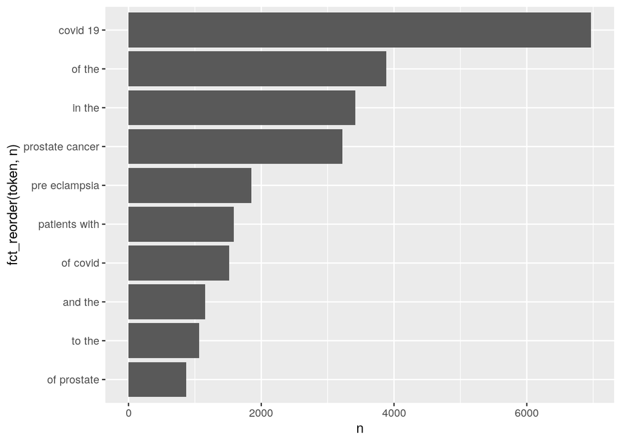

```r
library(ggplot2)

mytext %>%
  unnest_ngrams(output= token,input=abstract,n=2) %>%
  count(token,sort=TRUE) %>%
  top_n(10,n) %>%
  ggplot(aes(fct_reorder(token,n), n)) + geom_col() + coord_flip()
```

3、Calculate the TF-IDF value for each word-search term combination. (here you want the search term to be the “document”) What are the 5 tokens from each search term with the highest TF-IDF value? How are the results different from the answers you got in question 1?

> TF-IDF = TF(Term Frequency) * IDF(Inverse Document Frequency) The word of value of TF-IDF is higher, this word is more likely to be a *keyword* … because, This word has a large numbers in whole file but has a low IDF(Inverse Document Frequency)

```r
##TF-IDF------keywords
mytext %>%
  unnest_tokens(word, abstract) %>%
  anti_join(stop_words,by=c("word")) %>%
  filter(!(word %in% as.character(seq(0,100)))) %>%    #remove number
  group_by(term) %>%      #grouped by "term" (for counting the top 5 words in each "term")
  count(word,sort=TRUE) %>%
  top_n(5,n) %>%
  bind_tf_idf(word, term, n) %>%
  arrange(desc(tf_idf))
```

```
## # A tibble: 26 x 6
## # Groups:   term [5]
##    term            word             n    tf   idf tf_idf
##    <chr>           <chr>        <int> <dbl> <dbl>  <dbl>
##  1 covid           covid         7275 0.577  1.61  0.929
##  2 prostate cancer cancer        3840 0.377  1.61  0.607
##  3 prostate cancer prostate      3832 0.376  1.61  0.606
##  4 meningitis      meningitis     429 0.289  1.61  0.464
##  5 cystic fibrosis fibrosis       867 0.260  1.61  0.418
##  6 cystic fibrosis cystic         862 0.258  1.61  0.415
##  7 preeclampsia    pre           2038 0.253  1.61  0.406
##  8 preeclampsia    eclampsia     2005 0.248  1.61  0.400
##  9 preeclampsia    preeclampsia  1863 0.231  1.61  0.372
## 10 cystic fibrosis cf             625 0.187  1.61  0.301
## # … with 16 more rows
```

*The top 3 tokens are the same to the tokens in Q1, but we can find some new words appear in the top 10 keywords Ranking, like meningitis,fibrosis and cystic. They have the low total number but have a very high tf_idf, which means they are the keywords in some terms.*